# Aula 03 - GLM Binário

Aline bueno, José Daniel Bastos e Juliana Moureira

2025-10-01

## 1 Introdução - GLMs e GLM Binomial

### 1.1 Modelos Lineares Generalizados (GLMs)

Os Modelos Lineares Generalizados (GLMs) compõem uma extensão dos modelos lineares tradicionais, assim abrangendo variáveis com distribuição diferente da normal e com variância não homocedástica. A estrutura geral dos GLMs diferencia-se de uma regressão linear simples, prinipalmente, devido a presença de função de ligação ($g(u_i)$) e um preditor linear ($n_1$), conforme enquação 1:

$$g(u_i) = n_1 = \beta_0 +
\sum_{0-1}^{p}\beta_j X_{ij}$$
Os GLMs possuem quatro componentes principais:

- 1° Componente - Distribuição de probabilidade da variável resposta.

Corresponde ao componente aleatório do modelo, onde $F$ pertence a uma família exponencial de distribuição. É uma propriedade relativa a natureza da variável predita. Essa distribuição pode ser descritas pelos seus momentos, que são as características de distribuição (e.g: média, variância, assimetria e curtose).

$$y_i \sim F(u, \Phi)$$

- 2° Componente - Preditor linear ($n_i$)

Trata-se de um componente sistemático do modelo, responsável por estabalecer a relação entre $y$ e $x$.

- 3° Componente - Função de ligação ($g(u_i)$)

Faz a ligação entre o preditor linear ($n_1$) e a média de distribuição $u_i$ (variável resposta), ou seja, é realizada a junção entre o componente aleatório e o sistemático. Nesse sentido, esse termo pode ser visto como um “tradutor”, garantindo que os valores de $n_1$ estejam dentro dos valores de $u_i$.

- Pressupostos

Assemelham-se aos pressupostos dos demais modelos lineares, como representatividade da amostra, aditividade, linearidade e independência dos resíduos. No caso dos GLMs, a escolha da distribuição de probabiliadade (modelo) deve ser condizente com a natureza da variável resposta.

### 1.2 GLM para dados binários

Assume apenas dois estados possíveis como, por exemplo, dados de presença e ausência; maturo e imaturo; macho e femea; etc. Como forma de inferir a probabilidade quando $n=1$, pode-se utilizar a distribuição de Bernoulli, onde:

$$y_i \sim Bernoulli (p_i)$$

Quando se tem um $n$ maior do que 1, pode-se trabalhar com a distribuição binomial, em que:

$$y_i \sim Binomial(n_i, p_i)$$
Ainda, pode-se adicionar um conjunto de covariáveis, como:

$$logit(p_i) = n_i = \beta_0 + y_i
\sum_{j=1}^p\beta_jX_{ij}$$
$\beta_1$ representa o efeit do aumento de uma unidade de x sobre o logaritmo da razão de chances (log-odds), onde $\beta_1 > 0$ representa o aumento do log-odds com $x$ enquanto $\beta_1 < 0$ representa a relação contrária.

Ainda, pode ser conveniente aplicar a função inversa como forma de interpretar parâmetros na escala original. No caso da distribuição binomial, o inverso de $log$ é $exp$, como visto em:

$$p_i/1-p_i = e^{\beta_0 +
\beta_1x_i}$$

## 2 Base de dados

O objetivo geral do relatório foi de: Avaliar com diferentes características oceanográficas afetam a ocorrência e captura acidental do peixe-lua (*Mola mola*). Assim, esperavamos que esse evento estaria relacionado a salinidade nos locais de estudo.

A base de dados escolhida foi a “fisheries.rds”, cujos objetivos principais são relativos a:

- Presença/ausência de diferentes espécies;
- Associar a presença de uma espécie à características oceanográficas;
- Transformar as abundâncias em variável binária (se y> 0, atribui-se 1; caso contrário, 0 (y=0)).

```r
#~~~~~~~~~~~~~~~~~~~~~~~~~~~~~~~~
# 1. Importando o banco de dados
#~~~~~~~~~~~~~~~~~~~~~~~~~~~~~~~~
fisheries <- readRDS("C:/Users/José/OneDrive/Área de Trabalho/Disciplinas mestrado/Modelos Lineares Generalizados e Aditivos/Disciplina_GLM_GAM/ECL0072-GLM_GAM-gh-pages/ECL0072-GLM_GAM-gh-pages/Dados/fisheries.rds")
```

É necessário escolher uma espécie e transformar os dados de abundância em presença/ausência. Assim, escolhi a primeira espécie *Mola mola*.

```r
library(dplyr)
## Relação com o peso individual ##
# Precisamos converter as categorias de peso em formato binário -> ifelse

fisheries$Mola_mola <- ifelse(fisheries$Mola_mola,1, 0)
```

Teste de colinearidade:

```r
### Centralizando as covariáveis numéricas
fisheries[,28:33] <- scale(fisheries[,28:33], scale=T, center=F)

library(GGally)
```

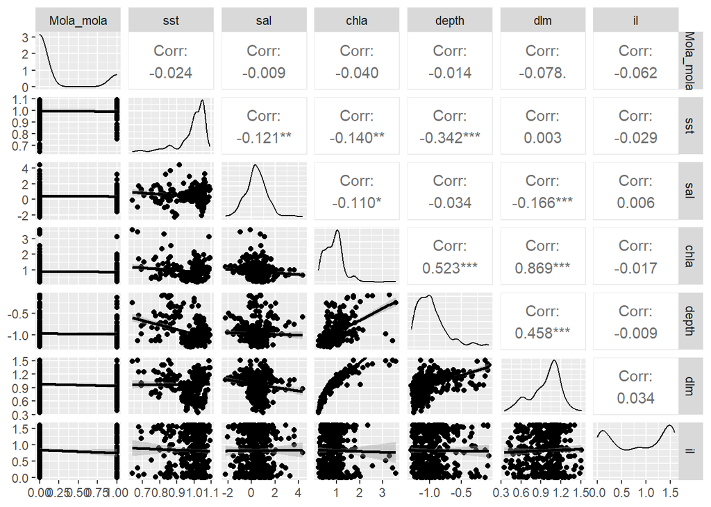

```r
ggpairs(fisheries,
        columns = c(18, 28:33),
        lower = list(continuous = "smooth")) # Columns
```

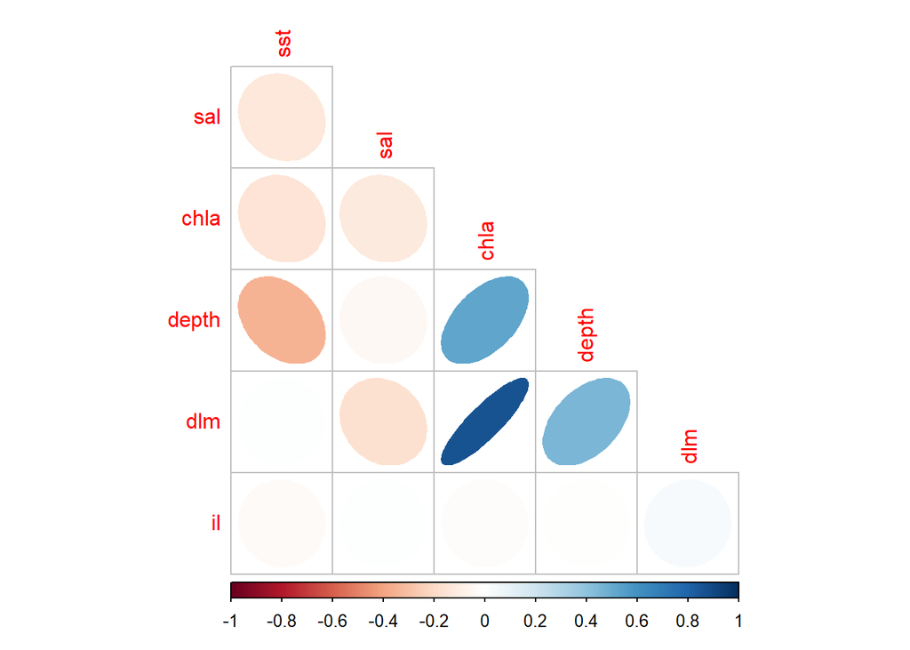

```r
# Coluna de ssp com covariáveis -> parece não ter relação
# dlm e chla são altamente correlacionadas -> escolher uma variável que faça mais sentido ecologicamente. Neste caso, chla (Concentração de clorofila)


## Há multicolinearidade!


m_cor <- cor(fisheries[, 28:33])
library(corrplot)
corrplot(m_cor, method = 'ellipse', diag = FALSE, type = 'lower')
```

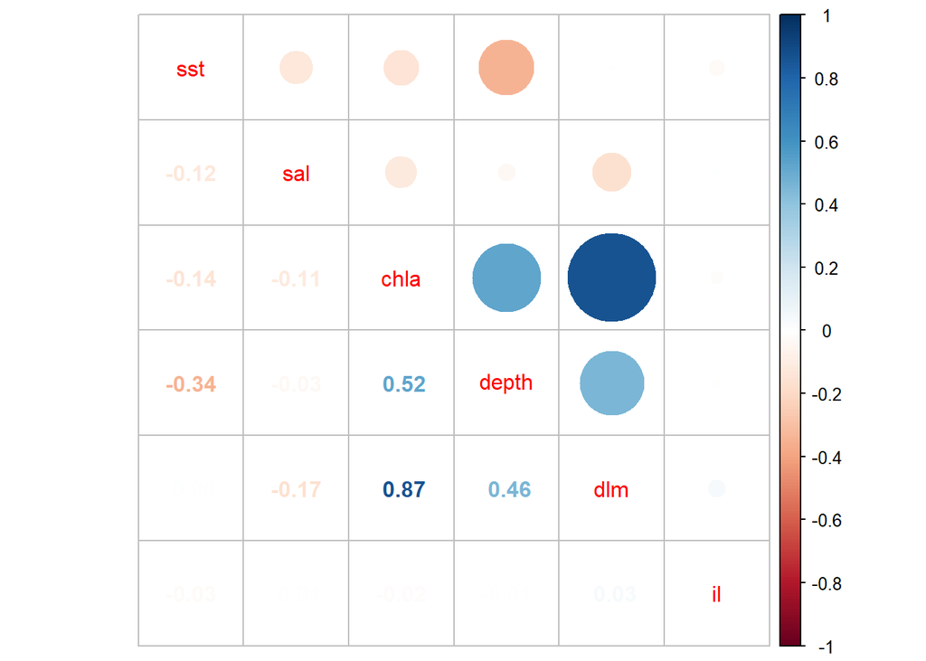

```r
corrplot.mixed(m_cor)
```

```r
#~~~~~~~~~~~~~~~~~~~~~~
# Testando modelos
#~~~~~~~~~~~~~~~~~~~~~~


## Modelo Nulo
mod0 <- glm(Mola_mola ~ 1,
            family = binomial(link = "logit"),
            data = fisheries)

## Modelo 1
mod1 <- glm(Mola_mola ~ sal,
            family = binomial(link = "logit"),
            data = fisheries)

## Modelo 2
mod2 <- glm(Mola_mola ~ sal + chla,
            family = binomial(link = "logit"),
            data = fisheries)

## Modelo 3
mod3 <- glm(Mola_mola ~  sal + chla + il,
            family = binomial(link = "logit"),
            data = fisheries)

# 4) Comparando os modelos
#~~~~~~~~~~~~~~~~~~~~~~~~~~~

## Calcular os valores de AIC ##
aic <- AIC(mod0, mod1, mod2, mod3)


## Ordenar dos menores aos maiores valores ##
library(dplyr)
aic %>% arrange(-AIC)
```

```
##      df      AIC
## mod3  4 466.8679
## mod2  3 466.7074
## mod1  2 465.5709
## mod0  1 463.6056
```

```r
summary(mod1)
```

```
##
## Call:
## glm(formula = Mola_mola ~ sal, family = binomial(link = "logit"),
##     data = fisheries)
##
## Coefficients:
##             Estimate Std. Error z value Pr(>|z|)
## (Intercept) -1.44639    0.12767 -11.329   <2e-16 ***
## sal         -0.02398    0.12875  -0.186    0.852
## ---
## Signif. codes:  0 '***' 0.001 '**' 0.01 '*' 0.05 '.' 0.1 ' ' 1
##
## (Dispersion parameter for binomial family taken to be 1)
##
##     Null deviance: 461.61  on 475  degrees of freedom
## Residual deviance: 461.57  on 474  degrees of freedom
## AIC: 465.57
##
## Number of Fisher Scoring iterations: 4
```

```r
## Teste de razão de verossimilhança ##

#lmtest::lrtest(mod3, mod2) # mesma coisa
#anova(mod3, mod2, test = "Chisq")


#~~~~~~~~~~~~~~~~~~~~~~~~
# 5) Validação do modelo
#~~~~~~~~~~~~~~~~~~~~~~~~
library(DHARMa)
```

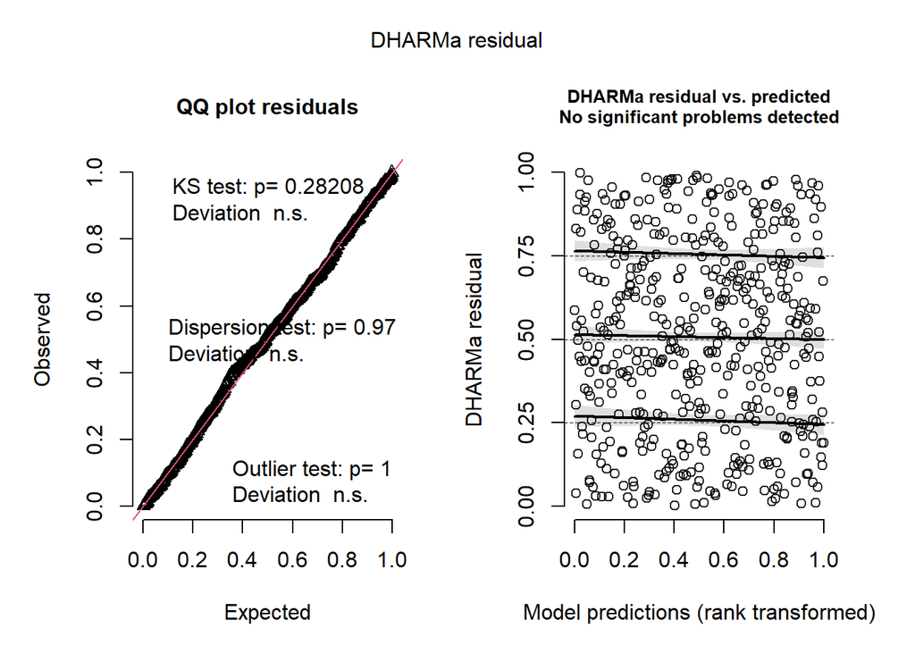

```r
## Simulando os resíduos a partir do modelo escolhido ##
resid_sim <- simulateResiduals(mod1, n=1000)

plot(resid_sim)
```

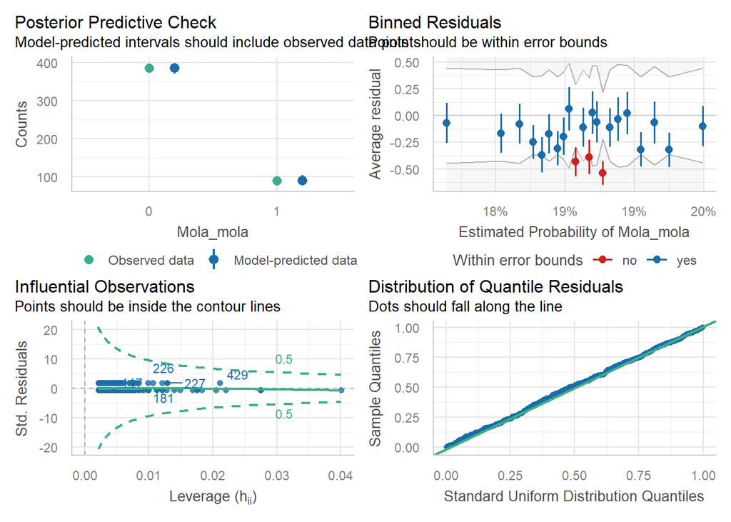

```r
library(performance)
check_model(mod1)
```

```r
## Teste de autocorrelação
check_autocorrelation(mod1)
```

```
## OK: Residuals appear to be independent and not autocorrelated (p = 0.282).
```

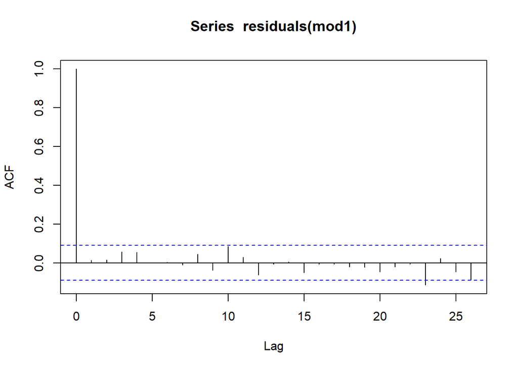

```r
acf(residuals(mod1))
```

```r
#~~~~~~~~~~~~~~~~~~~~~~~~~~~~
# 6) Analisando os resultados
#~~~~~~~~~~~~~~~~~~~~~~~~~~~
summary(mod1)
```

```
##
## Call:
## glm(formula = Mola_mola ~ sal, family = binomial(link = "logit"),
##     data = fisheries)
##
## Coefficients:
##             Estimate Std. Error z value Pr(>|z|)
## (Intercept) -1.44639    0.12767 -11.329   <2e-16 ***
## sal         -0.02398    0.12875  -0.186    0.852
## ---
## Signif. codes:  0 '***' 0.001 '**' 0.01 '*' 0.05 '.' 0.1 ' ' 1
##
## (Dispersion parameter for binomial family taken to be 1)
##
##     Null deviance: 461.61  on 475  degrees of freedom
## Residual deviance: 461.57  on 474  degrees of freedom
## AIC: 465.57
##
## Number of Fisher Scoring iterations: 4
```

Este conteúdo está disponível por meio da Licença Creative Commons 4.0